# Electric Power Consumption & CO₂ Emissions Forecasting

Time Series Analysis | Europe & Central Asia | 1981–2023

Tracy Nguyen

2026-05-08

# 1 Overview

This report analyses **electric power consumption per capita** across Europe & Central Asia from 1981 to 2023, and its relationship with **CO₂ emissions from waste**. Five forecasting models were built and evaluated against the actual 2023 value.

**Techniques used:** Data wrangling · Missing value imputation · Outlier detection · Stationarity testing (ADF) · Moving Average · ARIMA · Exponential Smoothing · ggplot2

# 2 Data Cleaning Summary

> Missing values in Electric Power Consumption were filled using **linear regression on CO₂ Emissions**, justified by a pre-imputation correlation of **r = 0.716**. Outliers were detected using the IQR rule and reviewed before and after imputation.

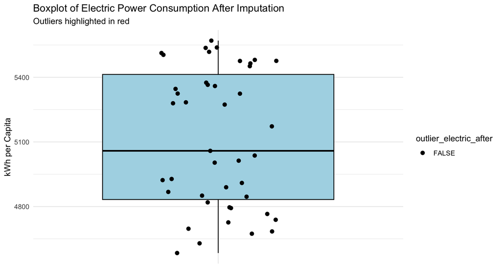

# 3 Time Series Analysis

## 3.1 Trend

> ACF analysis found **no clear seasonality** — the series shows a slow decay indicating a dominant **upward trend**. Linear regression confirms an increase of approximately **21 kWh per capita per year** (R² = 0.685, p < 0.001).

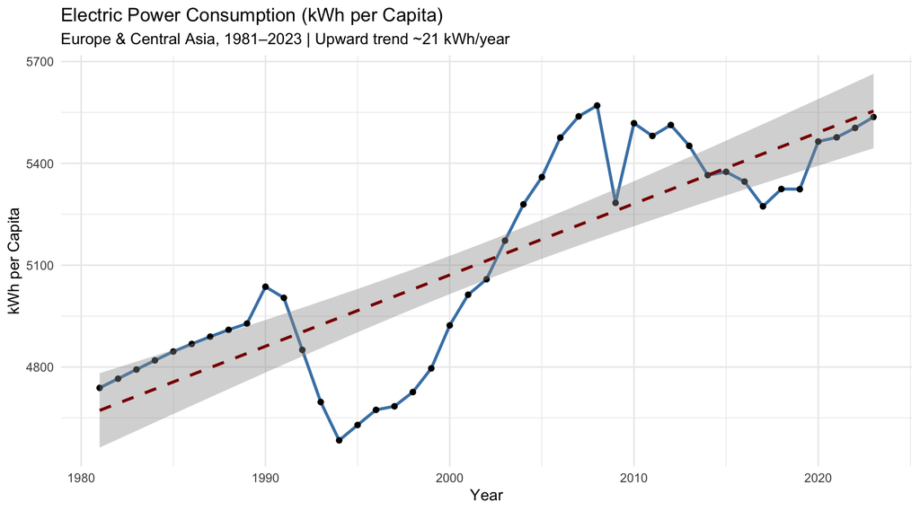

## 3.2 Residuals (Irregular Component)

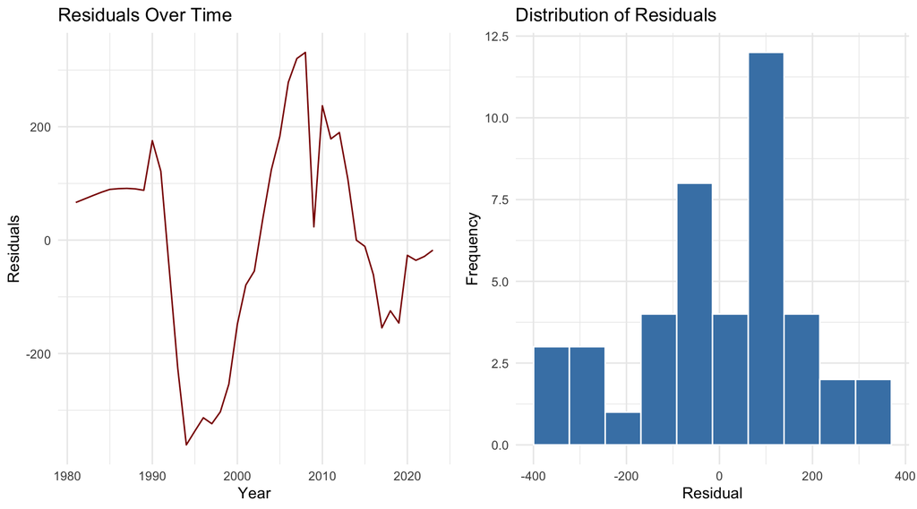

# 4 Forecasting Models

> Models were trained on **1981–2022** data. The actual 2023 value (**5,536 kWh**) was used as a hold-out to evaluate forecast accuracy.

## 4.1 Accuracy Comparison

Model Accuracy Metrics — Training Set (1981–2022)

|  | RMSE | MAE | MAPE |
| --- | --- | --- | --- |
| MA(1) | 90.198 | 66.366 | 1.293 |
| MA(2) | 87.505 | 59.910 | 1.169 |
| ARIMA | 90.502 | 67.245 | 1.312 |
| SES | 90.500 | 67.137 | 1.310 |
| Holt’s Linear | 88.615 | 60.008 | 1.168 |

> **MA(2)** achieved the lowest RMSE and MAE overall. **Holt’s Linear Trend** was closest to the actual 2023 value.

## 4.2 Forecast Plots

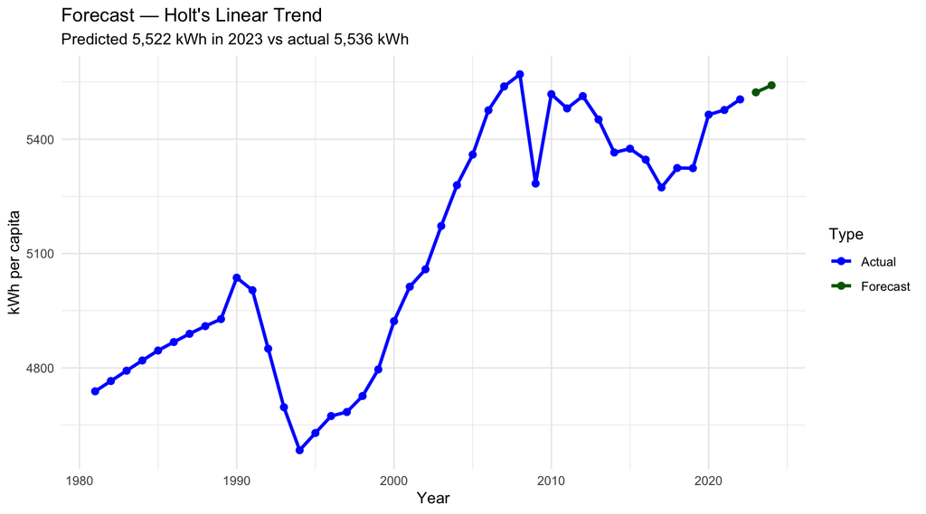

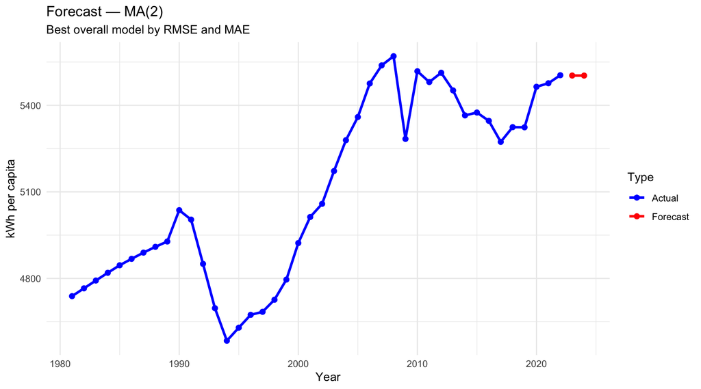

# 5 Relationship: Electricity vs CO₂ Emissions

> Correlation coefficient after imputation: **r = 0.829** — a strong positive relationship confirming that electricity consumption is a reliable proxy for CO2 emissions in this region.

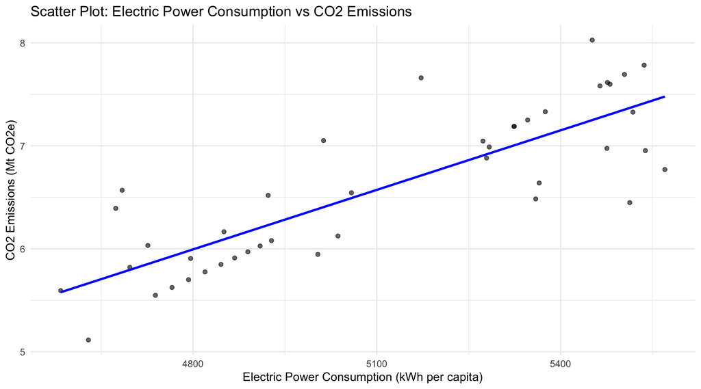

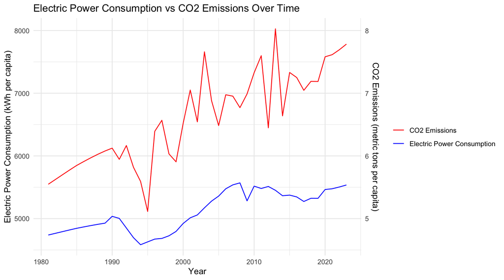

# 6 Key Findings

|  | Finding |
| --- | --- |
| 📈 **Trend** | ~21 kWh per capita increase per year (R² = 0.685) |
| 🏆 **Best overall model** | MA(2) — lowest RMSE and MAE |
| 🎯 **Best short-term model** | Holt’s Linear — predicted 5,522 vs actual 5,536 in 2023 |
| 🔗 **Correlation** | r = 0.829 between electricity and CO₂ emissions |
| 🔮 **2024 forecast** | ~5,537–5,540 kWh per capita (continued growth) |

*Analysis by Tracy Nguyen | ANL557 Applied Forecasting | SUSS 2025*